# 02 Creación de Mapas en R

Dr. Victor Augusto Lizcano S.

2023-11-29

## Mapas en R

Para poder visualizar nuestros mapas con un conjunto de datos vectoriales vamos a emplear la librería “ggplot2”. También emplearemos la librería “rnaturalearth” la cual nos proporciona mapas de todo el mundo.

```r
library(ggplot2)
library(rnaturalearth)
library(rnaturalearthdata)
library(sp)
library(raster)
theme_set(theme_bw()) ##?theme_bw establece el tema en blanco y negro es una función de ggplot2

elMundo <- ne_countries(scale = "medium", returnclass = "sf") #Retorna poligonos de cada país del mundo, la escala media es de 1:50, la escala larga de 1:10 y la escala pequeña de 1:110. La clase de retorno puede ser sp o sf para datos espaciales

str(elMundo)
```

```
## Classes 'sf' and 'data.frame':   241 obs. of  64 variables:
##  $ scalerank : int  3 1 1 1 1 3 3 1 1 1 ...
##  $ featurecla: chr  "Admin-0 country" "Admin-0 country" "Admin-0 country" "Admin-0 country" ...
##  $ labelrank : num  5 3 3 6 6 6 6 4 2 6 ...
##  $ sovereignt: chr  "Netherlands" "Afghanistan" "Angola" "United Kingdom" ...
##  $ sov_a3    : chr  "NL1" "AFG" "AGO" "GB1" ...
##  $ adm0_dif  : num  1 0 0 1 0 1 0 0 0 0 ...
##  $ level     : num  2 2 2 2 2 2 2 2 2 2 ...
##  $ type      : chr  "Country" "Sovereign country" "Sovereign country" "Dependency" ...
##  $ admin     : chr  "Aruba" "Afghanistan" "Angola" "Anguilla" ...
##  $ adm0_a3   : chr  "ABW" "AFG" "AGO" "AIA" ...
##  $ geou_dif  : num  0 0 0 0 0 0 0 0 0 0 ...
##  $ geounit   : chr  "Aruba" "Afghanistan" "Angola" "Anguilla" ...
##  $ gu_a3     : chr  "ABW" "AFG" "AGO" "AIA" ...
##  $ su_dif    : num  0 0 0 0 0 0 0 0 0 0 ...
```

[output cut: 56 more lines]

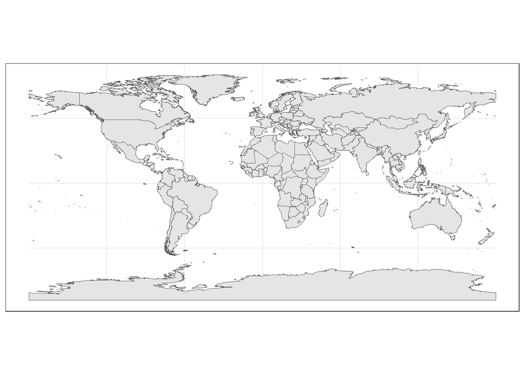

```r
#Ahora grafiquemos nuestro mapa

ggplot(data = elMundo) + geom_sf()
```

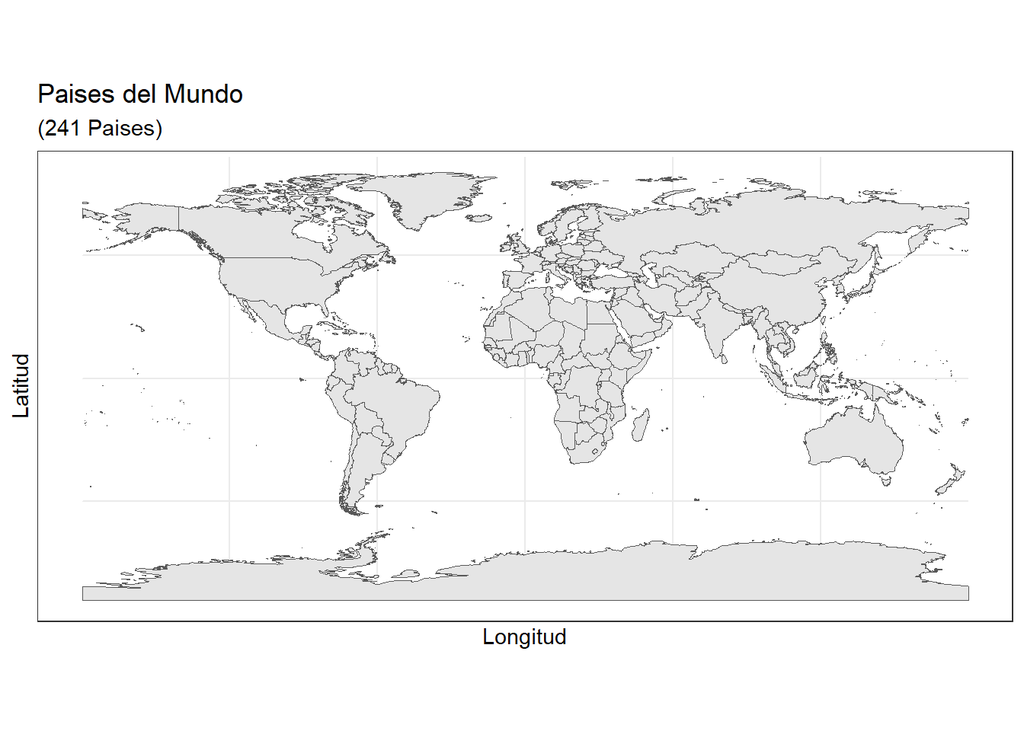

```r
#Decoremos nuestro mapa

ggplot(data = elMundo) + geom_sf() + xlab("Longitud") + ylab("Latitud") +
  ggtitle("Paises del Mundo", subtitle = paste0("(", length(unique(elMundo$name)), " Paises)"))
```

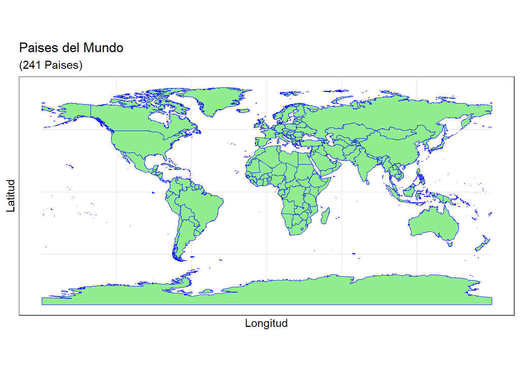

```r
#Asignemosle colores

ggplot(data = elMundo) + geom_sf(color="blue", fill = "lightgreen") + xlab("Longitud") + ylab("Latitud") +
  ggtitle("Paises del Mundo", subtitle = paste0("(", length(unique(elMundo$name)), " Paises)"))
```

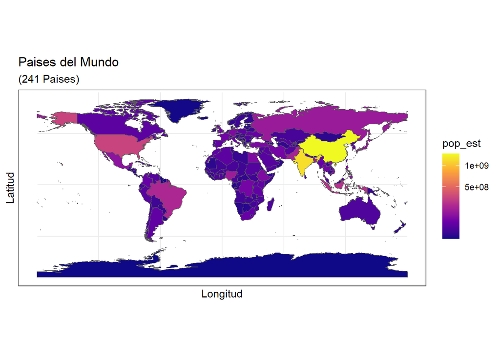

```r
ggplot(data = elMundo) + geom_sf(aes(fill = pop_est)) + # pop_est es una de las variables contenidas en el dataset "elMundo"
  scale_fill_viridis_c(option = "plasma", trans = "sqrt")+ #plasma es la variante de colores y sqrt la raíz de la población
  xlab("Longitud") + ylab("Latitud") +
  ggtitle("Paises del Mundo", subtitle = paste0("(", length(unique(elMundo$name)), " Paises)"))
```

## Proyección y extensión

Los sistemas de coordenadas geográficas se basan en una superficie esferoidal (ya sea verdaderamente esférica o elipsoidal) que se aproxima a la superficie de la Tierra. Un **datum** suele definir la superficie (radio para una esfera, eje mayor y eje menor o aplanamiento inverso para un elipsoide) y la posición de la superficie en relación con el centro de la Tierra. Por ejemplo:

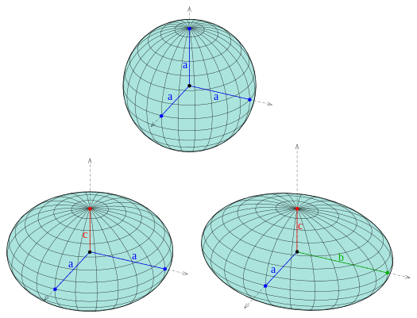

Elipsoides donde a, b y c son las longitudes de los semiejes del elipsoide respecto de los ejes x, y, z

[output not shown]

[El geoide, el elipsoide, el esferoide y el datum, y cómo se relacionan](https://help.arcgis.com/es/arcgisdesktop/10.0/help/index.html#//003r00000003000000)

Todo sistema de referencia de coordenadas geográficas hace referencia (valga la redundancia) a un **datum**. Por otra parte tenga en cuenta que este src no se proyecta y se representa en latitud y longitud.

Por otra parte, los sistemas de referencia de coordenadas proyectados, son transformaciones que convierten un conjunto de puntos de una superficie curva (es decir está en coordenadas geográficas) en una superficie plana (generalmente medida en metros).

El datum es una parte integral de la proyección, ya que los sistemas coordinados proyectados se basan en coordenadas geográficas, que a su vez están referenciadas a un datum. Es posible, e incluso común, que los datasets estén en la misma proyección, pero que se haga referencia a diferentes datums y, por lo tanto, tengan diferentes valores de coordenadas. Por ejemplo, se puede hacer referencia a los sistemas de coordenadas del plano de estado a los datums NAD83 y NAD27. Las transformaciones de coordenadas geográficas a coordenadas proyectadas son las mismas, pero como las coordenadas geográficas son diferentes en función del datum, las coordenadas proyectadas resultantes también serán diferentes.

Miremos algunos ejemplos en R:

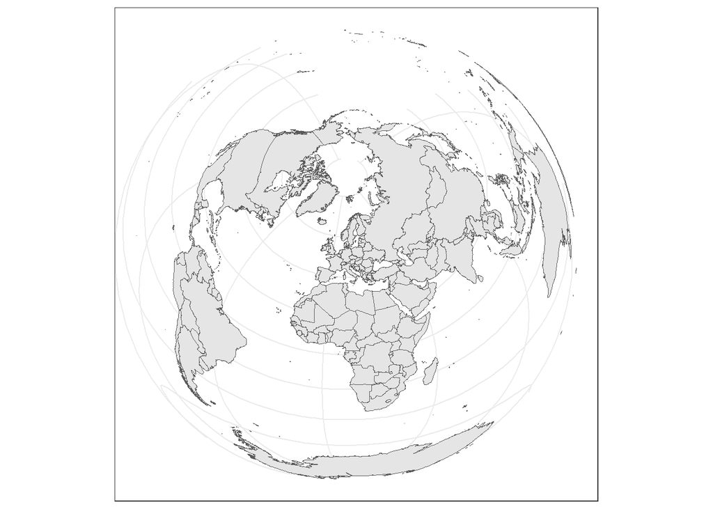

```r
ggplot(data = elMundo) +
    geom_sf() +
    coord_sf(crs = "+proj=laea +lat_0=52 +lon_0=10 +x_0=4321000 +y_0=3210000 +ellps=GRS80 +units=m +no_defs")
```

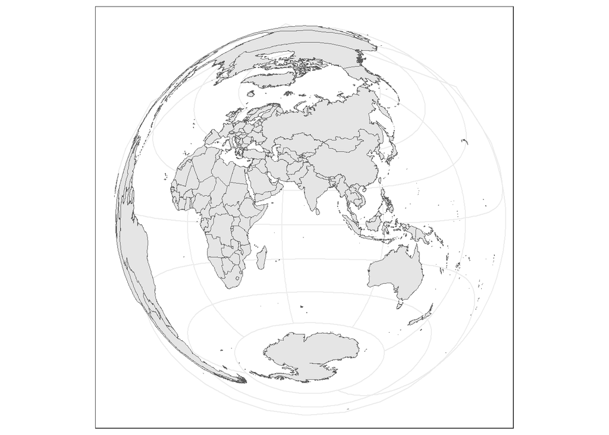

```r
# Los parámetros +lat_0=52, +lon_0=10, +x_0=4321000 y +y_0=3210000 son parámetros de la proyección de Lambert Azimuthal Equal Area (LAEA).

# La proyección LAEA es una proyección cartográfica que preserva el área y la forma de los continentes, pero distorsiona la distancia y la dirección. Esta proyección se utiliza comúnmente para representar regiones polares y se basa en un punto central que se utiliza como origen de coordenadas. Los parámetros +lat_0 y +lon_0 definen la latitud y longitud del punto central, mientras que +x_0 y +y_0 definen las coordenadas del punto central en metros.

#+proj=laea: es el tipo de proyección que se está utilizando, en este caso, Lambert Azimuthal Equal Area (LAEA).
#+lat_0=52: es el paralelo de origen en grados, que es la latitud en la que el plano del mapa toca la esfera terrestre.
#+lon_0=10: es el meridiano central en grados, que es la longitud en la que el plano del mapa toca la esfera terrestre.
#+x_0=4321000 y +y_0=3210000:son los falsos este y norte respectivamente. Son las coordenadas en el sistema de proyección que corresponden a la latitud y longitud de origen.
#+ellps=GRS80:es el elipsoide de referencia que se está utilizando.
#+units=m: es la unidad de medida utilizada en el sistema de proyección6.
#+no_defs: este argumento se utiliza para suprimir la carga de las definiciones de elipsoide y datum por defecto


# Cambiemos la longitud y latitud en la que el plano del mapa toca la esfera en 76,3

ggplot(data = elMundo) +
    geom_sf() +
    coord_sf(crs = "+proj=laea +lat_0=3 +lon_0=76 +ellps=GRS80 +units=m +no_defs")
```

Recordemos que la **proyección** es el método empleado para traducir una posición en el globo o geoide en una posición en un mapa bidimensional (es decir con x,y coordenadas). Las proyecciones pueden preservar ciertas propiedades como el área, la dirección (ángulos) o las longitudes. En el caso del **elipsoide**, este es un modelo matemático o de referencia empleado para aproximar la forma de la superficie terrestre. Este se basa en una serie de parámetros que definen la longitud del eje mayor, la longitud del eje menor y la forma general del elipsoide. Estos parámetros se utilizan para calcular la latitud, la longitud y la altitud de un punto en la Tierra.

**Nota:** el falso este y el falso norte son valores lineales que se aplican al origen de las coordenadas x e y, respectivamente. Se utilizan en los sistemas de coordenadas proyectadas para asegurar que todas las coordenadas x e y sean positivas ([Ver](https://help.arcgis.com/en/geodatabase/10.0/sdk/arcsde/concepts/geometry/coordref/coordsys/projected/mapprojections.htm)).

A continuación vamos a ver visualizacions de nuestro mapa mundi empleando identificadores EPSG para algunos SRC ([Ver más](https://spatialreference.org/ref/epsg/?page=1)).

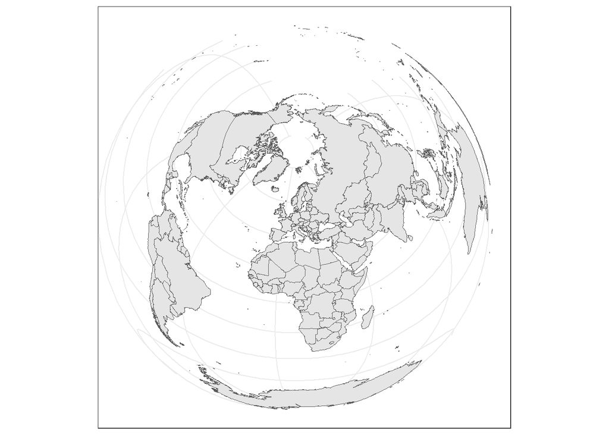

```r
#epsg 3035
#+proj=laea +lat_0=52 +lon_0=10 +x_0=4321000 +y_0=3210000 +ellps=GRS80 +units=m +no_defs
#https://spatialreference.org/ref/epsg/3035/

ggplot(data = elMundo) +
    geom_sf() +
    coord_sf(crs = "+init=epsg:3035")
```

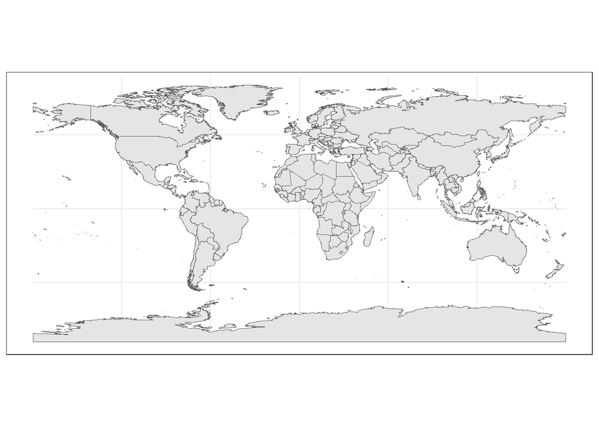

```r
#epsg 4326
#+proj=longlat +ellps=WGS84 +datum=WGS84 +no_defs
#https://spatialreference.org/ref/epsg/4326/
ggplot(data = elMundo) +
    geom_sf() +
    coord_sf(crs = "+init=epsg:4326")
```